# Assigment1

## 5) Discussing the results

### Was the feature selection successful? Report how many features were needed for the final performance. Plot the trace of evolution and comment on the change of fitness through generations.

From the plot we can see that the accuracy within the subsets with more than 30 features is not increasing anymore.

```r
control <- rfeControl(functions = rfFuncs,
                   method = "repeatedcv",
                   number = 3,
                   verbose = FALSE)
outcomeName <- 'class'
predictors <- names(learn)[!names(learn) %in% outcomeName]
results <- rfe(learn[,predictors], learn[,outcomeName], rfeControl=control,
               sizes = c(1, 2, 4, 6, 8, 12, 16, 20, 32, 64, 128, 256, 512, 1000))
results
```

```
##
## Recursive feature selection
##
## Outer resampling method: Cross-Validated (3 fold, repeated 1 times)
##
## Resampling performance over subset size:
##
##  Variables Accuracy  Kappa AccuracySD  KappaSD Selected
##          1   0.6813 0.1510   0.040665 0.156519
##          2   0.7918 0.4219   0.081832 0.197193
##          4   0.8069 0.4715   0.092658 0.237056
##          6   0.9016 0.7208   0.100038 0.267553        *
##          8   0.8387 0.5410   0.081126 0.187369
##         12   0.8251 0.4863   0.029194 0.018719
##         16   0.7933 0.3702   0.056454 0.117144
##         20   0.7933 0.3702   0.056454 0.117144
##         32   0.8418 0.4750   0.020742 0.046758
##         64   0.8418 0.4974   0.020742 0.008093
##        128   0.8251 0.4217   0.029194 0.129230
##        256   0.7774 0.1989   0.030038 0.173767
##        512   0.8092 0.3232   0.009094 0.084745
##        999   0.7759 0.2020   0.065875 0.263852
##
## The top 5 variables (out of 6):
##    atHG1996.HT2044_at, atX13100_s_at, atU16812_s_at, atHG3546.HT3744_s_at, atU14187_at
```

```r
predictors(results)
```

```
## [1] "atHG1996.HT2044_at"   "atX13100_s_at"        "atU16812_s_at"
## [4] "atHG3546.HT3744_s_at" "atU14187_at"          "atU01337_at"
```

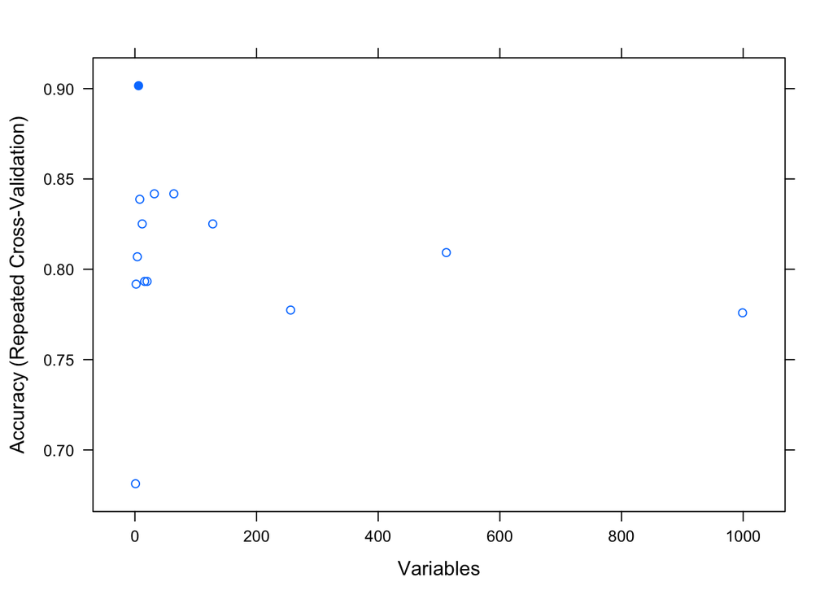

```r
plot(results)
```

### Suggest how to improve the selection process.

We could use variables that have a high influence of the class instead of selecting random ones.

### The procedure might overfit the data set. How would you prevent it?

We would just run different tests with different ammounts of features and test cases and then we would test the results to see which quantity is actually the best one

### What are some of the key properties of the fitness function?

The fitness function represent the number of successes while testing our classifier. The more successes we have the more our function fits the model

### Compare the final result (set of features) with the same number of features, that correlate the most with the target variable

```r
#result <- genes[, predictors(results)]
result <- genes[, results$optVariables]
topCor <- data.frame(imp)
topCor$Vars <- row.names(topCor)
topCor <- topCor[order(-topCor$Overall),][1:6,]$Vars
cors <- genes[, topCor]
correlation <- head(round(cor(result, cors),2))

correlation
```

```
##                      atU14187_at atU59831_rna1_s_at atU65416_rna1_s_at
## atHG1996.HT2044_at          0.80               0.59              -0.42
## atX13100_s_at               0.23               0.30              -0.21
## atU16812_s_at              -0.04               0.05              -0.05
## atHG3546.HT3744_s_at       -0.06              -0.04               0.05
## atU14187_at                 1.00               0.59              -0.41
## atU01337_at                 0.11               0.08              -0.09
##                      atU84388_at atX67491_f_at atS80905_f_at
## atHG1996.HT2044_at          0.14          0.18         -0.32
## atX13100_s_at               0.02          0.61          0.26
## atU16812_s_at              -0.13         -0.09          0.37
## atHG3546.HT3744_s_at       -0.18         -0.24          0.22
## atU14187_at                 0.14          0.18         -0.29
## atU01337_at                -0.15          0.16          0.01
```

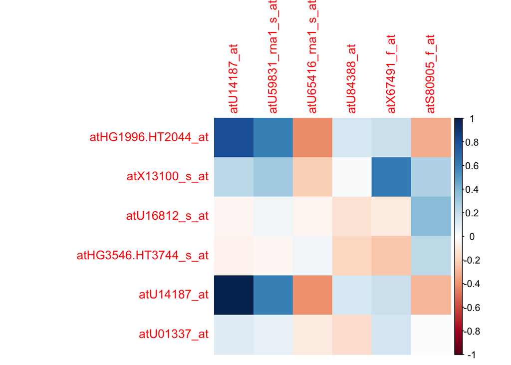

```r
corrplot(correlation, method="color")
```